# Exponential Random Graph Models (ERGMs) using statnet

Statnet Development Team

*Last updated 2019-06-18*

*This tutorial is a joint product of the Statnet Development Team:*

Martina Morris (University of Washington)  
Pavel N. Krivitsky (University of Wollongong)  
Mark S. Handcock (University of California, Los Angeles)  
Carter T. Butts (University of California, Irvine)  
David R. Hunter (Penn State University)  
Steven M. Goodreau (University of Washington)  
Skye Bender de-Moll (Oakland, CA)

The network modeling software demonstrated in this tutorial is authored by Pavel Krivitsky (`ergm`) and Carter Butts (`network` and `sna`).

## The `statnet` Project

All `statnet` packages are open-source, written for the **R** computing environment, and published on CRAN. The source repositories are hosted on [GitHub](https://github.com/statnet).

- Need help? For general questions and comments, please email the statnet users group [mailing list](https://statnet.org/trac/wiki/FrequentlyAskedQuestions#statnetusersgroup). (Note you’ll need to join first)
- Found a bug in our software? Please let us know by filing an issue in the appropriate package [GitHub repository](https://github.com/statnet), with a reproducible example.
- Want to request some new functionality? We welcome suggestions – you can make a request by filing an issue on the appropriate package [GitHub repository](https://github.com/statnet). The chances that this functionality will be developed are substantially improved if the requests are accompanied by some proposed code (we are happy to review pull requests).

## Introduction to this workshop/tutorial.

This workshop and tutorial provide an overview of statistical modeling of network data with *Exponential family Random Graph Models* (ERGMs) using `statnet` software. This online tutorial is also designed for self-study, with example code and self-contained data. The `statnet` packages we will be demonstrating are:

- `network` – storage and manipulation of network data
- `sna` – descriptive statistics and graphics for exploratory network analysis`
- `ergm` – statistical tools for estimating ERGMs, model assessment, and network simulation.

### Prerequisites

This workshop assumes basic familiarity with **R**, experience with network concepts, terminology and data, and familiarity with the general framework for statistical modeling and inference. While previous experience with ERGMs is not required, some of the topics covered here may be difficult to understand without a strong background in linear and generalized linear models in statistics.

### Software installation

Minimally, you will need to install the latest version of **R** [(available here)](https://cran.r-project.org) and the `statnet` packages `ergm` and `sna` to run the code presented here (`ergm` will automatically install `network`).  
The workshops are conducted using the free version of `Rstudio` [(available here)](https://rstudio.org).

The full set of installation intructions with details can be found on the [`statnet` workshop wiki](https://github.com/statnet/Workshops/wiki/Software-Installation-Instructions).

If you have not already downloaded the `statnet` packages for this workshop, the quickest way to install these (and the other most commonly used packages from the `statnet` suite), is to open an R session and type:

```r
install.packages('statnet')
```

```r
library(statnet)
```

Set a seed for simulations – this is not necessary, but it ensures that you will get the same results as the online tutorial (if we execute the same commands in the same order).

```r
set.seed(0)
```

## 1. Statistical network modeling with ERGMs

This is a *very brief* overview of the modeling framework, as the primary purpose of this tutorial is to show how to implement statistical analysis of network data with ERGMs using the `statnet` software tools. For more detail (and to really understand ERGMs) please see the references at the end of this tutorial.

Exponential-family random graph models (ERGMs) are a general class of models based in exponential-family theory for specifying the probability distribution for a set of random graphs or networks. Within this framework, one can—among other tasks:

- Define a model for a network that includes covariates representing features like homophily, mutuality, triad effects, and a wide range of other structural features of interest;
- Obtain maximum-likehood estimates for the parameters of the specified model for a given data set;
- Test individual coefficients, assess models for convergence and goodness-of-fit and perform various types of model comparison; and
- Simulate new networks from the underlying probability distribution implied by the fitted model.

### The general form for an ERGM

ERGMs are a class of models, like linear regression or GLMs. The general form of the model specifies the probability of the entire network (the left hand side), as a function of terms that represent network features we hypothesize may occur more or less likely than expected by chance (the right hand side). The general form of the model can be written as:

$$P(Y=y)=\frac{\exp(\theta'g(y))}{k(\theta)}$$

where

- $Y$ is the random variable for the state of the network (with realization $y$),
- $g(y)$ is a vector of model statistics for network $y$,
- $\theta$ is the vector of coefficients for those statistics, and
- $k(\theta)$ represents the quantity in the numerator summed over all possible networks (typically constrained to be all networks with the same node set as $y$).

If you’re not familiar with the compact notation here, note that the numerator represents a formula that is linear in the log form:

$$\log({\exp(\theta'g(y))}) = \theta_1g_1(y) + \theta_2g_2(y)+ ... + \theta_pg_p(y)$$
where $p$ is the number of terms in the model. From this one can more easily observe the analogy to a traditional statistical model: the coefficients $\theta$ represent the size and direction of the effects of the covariates $g(y)$ on the overall probability of the network.

### The model statistics $g(y)$: ERGM terms

The statistics $g(y)$ can be thought of as the “covariates” in the model. In the network modeling context, these represent network features like density, homophily, triads, etc. In one sense, they are like covariates you might use in other statistical models. But they are different in one important respect: these $g(y)$ statistics are functions of the network itself – each is defined by the frequency of a specific configuration of dyads observed in the network – so they are not measured by a question you include in a survey (e.g., the income of a node), but instead need to be computed on the specific network you have, after you have collected the data.

As a result, every term in an ERGM must have an associated algorithm for computing its value for your network. The `ergm` package in `statnet` includes about 150 term-computing algorithms. We will explore some of these terms in this tutorial, and links to more information are provided in section 3..

You can get the list of all available terms, and the syntax for using them, by typing:

```r
?'ergm-terms'
```

You can also search for terms with keywords:

```r
search.ergmTerms(keyword='homophily')
```

```
Found  13  matching ergm terms:
b1degrange(from, to=+Inf, by=NULL, homophily=FALSE, levels=NULL)
 Degree range for the first mode in a bipartite (a.k.a. two-mode) network

b1nodematch(attr, diff=FALSE, keep=NULL, alpha=1, beta=1,)
 Nodal attribute-based homophily effect for the first mode in a bipartite (aka two-mode) network

b2degrange(from, to=+Inf, by=NULL, homophily=FALSE, levels=NULL)
 Degree range for the second mode in a bipartite (a.k.a. two-mode) network

b2nodematch(attr, diff=FALSE, keep=NULL, alpha=1, beta=1,)
 Nodal attribute-based homophily effect for the second mode in a bipartite (aka two-mode) network

degrange(from, to=+Inf, by=NULL, homophily=FALSE, levels=NULL)
 Degree range

degree(d, by=NULL, homophily=FALSE, levels=NULL)
 Degree

idegrange(from, to=+Inf, by=NULL, homophily=FALSE, levels=NULL)
 In-degree range

idegree(d, by=NULL, homophily=FALSE, levels=NULL)
 In-degree

nodematch(attr, diff=FALSE, keep=NULL, levels=NULL)
 Uniform homophily and differential homophily

nodematch(attr, diff=FALSE, keep=NULL, levels=NULL, form="sum")
 Uniform homophily and differential homophily

match()
 Uniform homophily and differential homophily

odegrange(from, to=+Inf, by=NULL, homophily=FALSE, levels=NULL)
 Out-degree range

odegree(d, by=NULL, homophily=FALSE, levels=NULL)
 Out-degree
```

For more information, see the vignette on `ergm-terms`:

```r
vignette('ergm-term-crossRef')
```

```
starting httpd help server ... done
```

One key distinction in model terms is worth keeping in mind: terms are either *dyad independent* or *dyad dependent*. Dyad *independent* terms (like nodal homophily terms) imply no dependence between dyads—the presence or absence of a tie may depend on nodal attributes, but not on the state of other ties. Dyad *dependent* terms (like degree terms, or triad terms), by contrast, imply dependence between dyads. Such terms have very different effects, and much of what is different about network models comes from these terms. They introduce complex cascading effects that can often lead to counter-intuitive and highly non-linear outcomes. In addition, a model with dyad dependent terms requires a different estimation algorithm, so when we use them below you will see some different components in the output.

### ERGM probabilities: at the tie-level

The ERGM expression for the probability of the entire graph shown above can be re-expressed in terms of the conditional log-odds of a single tie between two actors:

$$\operatorname{logit}{(Y_{ij}=1|y^{c}_{ij})=\theta'\delta(y_{ij})}$$

where

- $Y_{ij}$ is the random variable for the state of the actor pair $i,j$ (with realization $y_{ij}$), and
- $y^{c}_{ij}$ signifies the complement of $y_{ij}$, i.e. all dyads in the network other than $y_{ij}$.
- $\delta(y_{ij})$ is a vector of the “change statistics” for each model term. The change statistic records how the $g(y)$ term changes if the $y_{ij}$ tie is toggled on or off. So:

$$\delta(y_{ij}) = g(y^{+}_{ij})-g(y^{-}_{ij})$$

where

- $y^{+}_{ij}$ is defined as $y^{c}_{ij}$ along with $y_{ij}$ set to 1, and
- $y^{-}_{ij}$ is defined as $y^{c}_{ij}$ along with $y_{ij}$ set to 0.

So $\delta(y_{ij})$ equals the value of $g(y)$ when $y_{ij}=1$ minus the value of $g(y)$ when $y_{ij}=0$, but all other dyads are as in $y$.

This expression shows that the coefficient $\theta$ can be interpreted as that term’s contribution to the log-odds of an individual tie, conditional on all other dyads remaining the same. The coefficient for each term in the model is multiplied by the number of configurations that tie will create (or remove) for that specific term. We will see exactly how this works in the sections that follow.

### Loading network data

Network data can come in many different forms — ties can be stored as edgelists or sociomatrices in .csv files, or as exported data from other programs like Pajek; attributes for the nodes, ties and dyads can also come in various forms. All can be read into *R* using either standard methods (for .csv files), or methods from the `network` package. For more information:

```r
?read.paj
?read.paj.simplify
?loading.attributes
```

However you read them in, the data will need to be transformed into a `network` object — the format that statnet uses to store and work with network data. For information on how to do this:

```r
?network
```

The `ergm` package also contains several network data sets, and we will use those here for demonstration purposes.

```r
data(package='ergm') # tells us the datasets in our packages
```

We’ll start with Padgett’s data on Renaissance Florentine families for our first example. As with all data analysis, we start by looking at our data using graphical and numerical descriptives.

```r
data(florentine) # loads flomarriage and flobusiness data
flomarriage # Look at the flomarriage network properties (uses `network`), esp. the vertex attributes
```

```
 Network attributes:
  vertices = 16
  directed = FALSE
  hyper = FALSE
  loops = FALSE
  multiple = FALSE
  bipartite = FALSE
  total edges= 20
    missing edges= 0
    non-missing edges= 20

 Vertex attribute names:
    priorates totalties vertex.names wealth

No edge attributes
```

```r
par(mfrow=c(1,2)) # Setup a 2 panel plot
plot(flomarriage,
     main="Florentine Marriage",
     cex.main=0.8,
     label = network.vertex.names(flomarriage)) # Plot the network
wealth <- flomarriage %v% 'wealth' # %v% references vertex attributes
wealth
```

```
 [1]  10  36  55  44  20  32   8  42 103  48  49   3  27  10 146  48
```

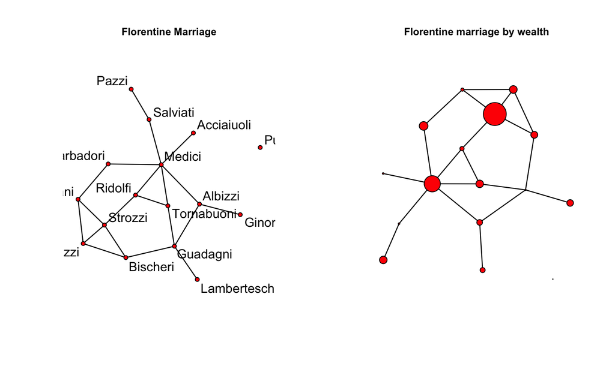

```r
plot(flomarriage,
     vertex.cex=wealth/25,
     main="Florentine marriage by wealth", cex.main=0.8) # Plot the network with vertex size proportional to wealth
```

### The `summary` and `ergm` functions, and supporting functions

We’ll start by running some simple models to demonstrate the most commonly used functions for ERG modeling.

The syntax for specifying a model in the `ergm` package follows **R**’s formula convention:

$$my.network \sim my.vector.of.model.terms$$

This syntax is used for both the `summary` and `ergm` functions. The `summary` function simply returns the numerical values of the network statistics in the model. The `ergm` function estimates the model with those statistics.

It is good practice to always run a `summmary` command on a model before fitting it with `ergm`. This is the ERGM equivalent of performing some descriptive analysis on your covariates. This can help you make sure you understand what the term represents, and it can help to flag potential problems that will lead to poor modeling results.

#### A simple Bernoulli (“Erdos/Renyi”) model

We begin with a simple model, containing only one term that represents the total number of edges in the network, $\sum{y_{ij}}$. The name of this ergm-term is `edges`, and when included in an ERGM its coefficient controls the overall density of the network.

```r
summary(flomarriage ~ edges) # Look at the $g(y)$ statistic for this model
```

```
edges
   20
```

```r
flomodel.01 <- ergm(flomarriage ~ edges) # Estimate the model
```

```
Starting maximum pseudolikelihood estimation (MPLE):
```

```
Evaluating the predictor and response matrix.
```

```
Maximizing the pseudolikelihood.
```

```
Finished MPLE.
```

```
Stopping at the initial estimate.
```

```
Evaluating log-likelihood at the estimate.
```

```r
summary(flomodel.01) # Look at the fitted model object
```

```
==========================
Summary of model fit
==========================

Formula:   flomarriage ~ edges

Iterations:  5 out of 20

Monte Carlo MLE Results:
      Estimate Std. Error MCMC % z value Pr(>|z|)
edges  -1.6094     0.2449      0  -6.571   <1e-04 ***
---
Signif. codes:  0 '***' 0.001 '**' 0.01 '*' 0.05 '.' 0.1 ' ' 1

     Null Deviance: 166.4  on 120  degrees of freedom
 Residual Deviance: 108.1  on 119  degrees of freedom

AIC: 110.1    BIC: 112.9    (Smaller is better.)
```

This simple model specifies a single homogeneous probability for all ties, which is captured by the coefficient of the `edges` term. How should we interpret this coefficient? The easiest way is to return to the logit form of the ERGM. The log-odds that a tie is present is
$$\small{
\begin{eqnarray*}
logit(p(y)) &=& \theta \times \delta(g(y)) \\
& = & -1.61 \times \mbox{change in the number of ties}\\
& = & -1.61 \times 1
\end{eqnarray*}
}$$
for every tie, since the addition of any tie to the network always increases the total number of ties by 1.

The corresponding probability is obtained by taking the expit, or inverse logit, of $\theta$:

$$\small{
\begin{eqnarray*}
& = & \exp(-1.61)/
(1+\exp(-1.61))\\
& = & 0.17
\end{eqnarray*}
}$$

This probability corresponds to the density we observe in the flomarriage network: there are $20$ ties and $\binom{16}{2} = (16 \times 15)/2 = 120$ dyads, so the probability of a tie is $20/120 = 0.17$.

#### Triad formation

Let’s add a term often thought to be a measure of “clustering”: the number of completed triangles in the network, or $\sum{y_{ij}y_{ik}y_{jk}} \div 3$. The name for this ergm-term is `triangle`.

This is an example of a dyad dependent term: The status of any triangle containing dyad $y_{ij}$ depends on the status of dyads of the form $y_{ik}$ and $y_{jk}$. This means that any model containing the ergm-term `triangle` has the property that dyads are not probabilistically independent of one another. As a result, the estimation algorithm automatically changes to MCMC, and because this is a form of stochastic estimation your results may differ slightly.

```r
summary(flomarriage~edges+triangle) # Look at the g(y) stats for this model
```

```
   edges triangle
      20        3
```

```r
flomodel.02 <- ergm(flomarriage~edges+triangle)
summary(flomodel.02)
```

```
==========================
Summary of model fit
==========================

Formula:   flomarriage ~ edges + triangle

Iterations:  2 out of 20

Monte Carlo MLE Results:
         Estimate Std. Error MCMC % z value Pr(>|z|)
edges     -1.6627     0.3506      0  -4.742   <1e-04 ***
triangle   0.1483     0.6017      0   0.246    0.805
---
Signif. codes:  0 '***' 0.001 '**' 0.01 '*' 0.05 '.' 0.1 ' ' 1

     Null Deviance: 166.4  on 120  degrees of freedom
 Residual Deviance: 108.1  on 118  degrees of freedom

AIC: 112.1    BIC: 117.6    (Smaller is better.)
```

Now, how should we interpret coefficients?

The conditional log-odds of two actors having a tie, keeping the rest of the network fixed, is
$$\small{
-1.66 \times\mbox{change in the number of ties} + 0.15 \times\mbox{change in number of triangles.}
}$$

- For a tie that will create no triangles, the conditional log-odds is: $-1.66$.
- if one triangle: $-1.66 + 0.15 = -1.51$
- if two triangles: $-1.66 + 2 \times0.15 = -1.37$
- the corresponding probabilities are 0.16, 0.18, and 0.20.

Let’s take a closer look at the ergm object that the function outputs:

```r
class(flomodel.02) # this has the class ergm
```

```
[1] "ergm"
```

```r
names(flomodel.02) # the ERGM object contains lots of components.
```

```
 [1] "coef"          "sample"        "sample.obs"    "iterations"
 [5] "MCMCtheta"     "loglikelihood" "gradient"      "hessian"
 [9] "covar"         "failure"       "network"       "newnetworks"
[13] "newnetwork"    "coef.init"     "est.cov"       "coef.hist"
[17] "stats.hist"    "steplen.hist"  "control"       "etamap"
[21] "ergm_version"  "MPLE_is_MLE"   "formula"       "target.stats"
[25] "target.esteq"  "constrained"   "constraints"   "reference"
[29] "estimate"      "offset"        "drop"          "estimable"
[33] "null.lik"      "mle.lik"
```

```r
flomodel.02$coef # you can extract/inspect individual components
```

```
     edges   triangle
-1.6627457  0.1483228
```

#### Nodal covariates: effects on mean degree

We saw earlier that wealth appeared to be associated with higher degree in this network. We can use `ergm` to test this. Wealth is a nodal covariate, so we use the ergm-term **nodecov**.

```r
summary(wealth) # summarize the distribution of wealth
```

```
   Min. 1st Qu.  Median    Mean 3rd Qu.    Max.
   3.00   17.50   39.00   42.56   48.25  146.00
```

```r
# plot(flomarriage,
#      vertex.cex=wealth/25,
#      main="Florentine marriage by wealth",
#      cex.main=0.8) # network plot with vertex size proportional to wealth
summary(flomarriage~edges+nodecov('wealth')) # observed statistics for the model
```

```
         edges nodecov.wealth
            20           2168
```

```r
flomodel.03 <- ergm(flomarriage~edges+nodecov('wealth'))
```

```
Starting maximum pseudolikelihood estimation (MPLE):
```

```
Evaluating the predictor and response matrix.
```

```
Maximizing the pseudolikelihood.
```

```
Finished MPLE.
```

```
Stopping at the initial estimate.
```

```
Evaluating log-likelihood at the estimate.
```

```r
summary(flomodel.03)
```

```
==========================
Summary of model fit
==========================

Formula:   flomarriage ~ edges + nodecov("wealth")

Iterations:  4 out of 20

Monte Carlo MLE Results:
                Estimate Std. Error MCMC % z value Pr(>|z|)
edges          -2.594929   0.536056      0  -4.841   <1e-04 ***
nodecov.wealth  0.010546   0.004674      0   2.256   0.0241 *
---
Signif. codes:  0 '***' 0.001 '**' 0.01 '*' 0.05 '.' 0.1 ' ' 1

     Null Deviance: 166.4  on 120  degrees of freedom
 Residual Deviance: 103.1  on 118  degrees of freedom

AIC: 107.1    BIC: 112.7    (Smaller is better.)
```

Question: What does the value of the **nodecov** statistic represent?

And yes, there is a significant positive wealth effect on the probability of a tie.

How do we interpret the coefficients here? Note that the wealth effect operates on both nodes in a dyad. The conditional log-odds of a tie between two actors is:

$$\small{
-2.59\times\mbox{change in the number of ties} + 0.01\times\mbox{the wealth of node 1} + 0.01\times\mbox{the wealth of node 2}
}$$

$$\small{
-2.59\times\mbox{change in the number of ties} + 0.01\times\mbox{the sum of the wealth of the two nodes}
}$$

- for a tie between two nodes with minimum wealth, the conditional log-odds is:  
  $-2.59 + 0.01*(3+3) = -2.53$
- for a tie between two nodes with maximum wealth:  
  $-2.59 + 0.01*(146+146) = 0.33$
- for a tie between the node with maximum wealth and the node with minimum wealth:  
  $-2.59 + 0.01*(146+3) = -1.1$
- The corresponding probabilities are 0.07, 0.58, and 0.25.

This model specification does not include a term for homophily by wealth, i.e., a term accounting for similarity in wealth of the two end nodes of a potential tie. It just specifies a relation between wealth and mean degree. To specify homophily on wealth, you could use the ergm-term *absdiff*. See section 3 below for more information on ergm-terms.?faux

#### Nodal covariates: Homophily

Let’s try a larger network, a simulated mutual friendship network based on one of the schools from the AddHealth study. Here, we’ll examine the homophily in friendships by grade and race. Both are discrete attributes so we use the ergm-term *nodematch*.

```r
data(faux.mesa.high)
mesa <- faux.mesa.high
```

```r
mesa
```

```
 Network attributes:
  vertices = 205
  directed = FALSE
  hyper = FALSE
  loops = FALSE
  multiple = FALSE
  bipartite = FALSE
  total edges= 203
    missing edges= 0
    non-missing edges= 203

 Vertex attribute names:
    Grade Race Sex

No edge attributes
```

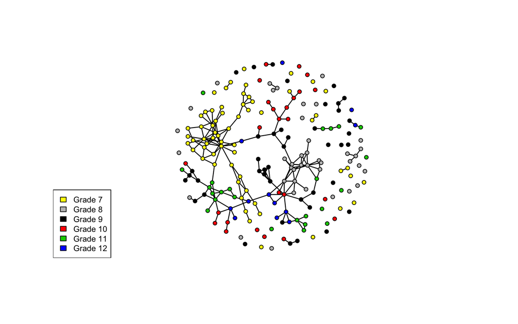

```r
par(mfrow=c(1,1)) # Back to 1-panel plots
plot(mesa, vertex.col='Grade')
legend('bottomleft',fill=7:12,
       legend=paste('Grade',7:12),cex=0.75)
```

```r
fauxmodel.01 <- ergm(mesa ~edges +
                       nodefactor('Grade') + nodematch('Grade',diff=T) +
                       nodefactor('Race') + nodematch('Race',diff=T))
```

```
Observed statistic(s) nodematch.Race.Black and nodematch.Race.Other are at their smallest attainable values. Their coefficients will be fixed at -Inf.
```

```
Starting maximum pseudolikelihood estimation (MPLE):
```

```
Evaluating the predictor and response matrix.
```

```
Maximizing the pseudolikelihood.
```

```
Finished MPLE.
```

```
Stopping at the initial estimate.
```

```
Evaluating log-likelihood at the estimate.
```

```r
summary(fauxmodel.01)
```

```
==========================
Summary of model fit
==========================

Formula:   mesa ~ edges + nodefactor("Grade") + nodematch("Grade", diff = T) +
    nodefactor("Race") + nodematch("Race", diff = T)

Iterations:  7 out of 20

Monte Carlo MLE Results:
                      Estimate Std. Error MCMC % z value Pr(>|z|)
edges                  -8.0538     1.2561      0  -6.412  < 1e-04 ***
nodefactor.Grade.8      1.5201     0.6858      0   2.216 0.026663 *
nodefactor.Grade.9      2.5284     0.6493      0   3.894  < 1e-04 ***
nodefactor.Grade.10     2.8652     0.6512      0   4.400  < 1e-04 ***
nodefactor.Grade.11     2.6291     0.6563      0   4.006  < 1e-04 ***
nodefactor.Grade.12     3.4629     0.6566      0   5.274  < 1e-04 ***
nodematch.Grade.7       7.4662     1.1730      0   6.365  < 1e-04 ***
nodematch.Grade.8       4.2882     0.7150      0   5.997  < 1e-04 ***
nodematch.Grade.9       2.0371     0.5538      0   3.678 0.000235 ***
nodematch.Grade.10      1.2489     0.6233      0   2.004 0.045111 *
nodematch.Grade.11      2.4521     0.6124      0   4.004  < 1e-04 ***
nodematch.Grade.12      1.2987     0.6981      0   1.860 0.062824 .
nodefactor.Race.Hisp   -1.6659     0.2963      0  -5.622  < 1e-04 ***
nodefactor.Race.NatAm  -1.4725     0.2869      0  -5.132  < 1e-04 ***
nodefactor.Race.Other  -2.9618     1.0372      0  -2.856 0.004296 **
nodefactor.Race.White  -0.8488     0.2958      0  -2.869 0.004112 **
nodematch.Race.Black      -Inf     0.0000      0    -Inf  < 1e-04 ***
nodematch.Race.Hisp     0.6912     0.3451      0   2.003 0.045153 *
nodematch.Race.NatAm    1.2482     0.3550      0   3.517 0.000437 ***
nodematch.Race.Other      -Inf     0.0000      0    -Inf  < 1e-04 ***
nodematch.Race.White    0.3140     0.6405      0   0.490 0.623947
---
Signif. codes:  0 '***' 0.001 '**' 0.01 '*' 0.05 '.' 0.1 ' ' 1

     Null Deviance: 28987  on 20910  degrees of freedom
 Residual Deviance:  1827  on 20889  degrees of freedom

AIC: 1869    BIC: 2036    (Smaller is better.)

 Warning: The following terms have infinite coefficient estimates:
  nodematch.Race.Black nodematch.Race.Other
```

Note that two of the coefficients are estimated as -Inf (the nodematch coefficients for race Black and Other). Why is this?

```r
table(mesa %v% 'Race') # Frequencies of race
```

```
Black  Hisp NatAm Other White
    6   109    68     4    18
```

```r
mixingmatrix(mesa, "Race")
```

```
Note:  Marginal totals can be misleading
 for undirected mixing matrices.
      Black Hisp NatAm Other White
Black     0    8    13     0     5
Hisp      8   53    41     1    22
NatAm    13   41    46     0    10
Other     0    1     0     0     0
White     5   22    10     0     4
```

The problem is that there are very few students in the Black and Other race categories, and these few students form no within-group ties. The empty cells are what produce the -Inf estimates.

Note that we would have caught this earlier if we had looked at the $g(y)$ stats at the beginning:

```r
summary(mesa ~edges  +
          nodefactor('Grade') + nodematch('Grade',diff=T) +
          nodefactor('Race') + nodematch('Race',diff=T))
```

```
                edges    nodefactor.Grade.8    nodefactor.Grade.9
                  203                    75                    65
  nodefactor.Grade.10   nodefactor.Grade.11   nodefactor.Grade.12
                   36                    49                    28
    nodematch.Grade.7     nodematch.Grade.8     nodematch.Grade.9
                   75                    33                    23
   nodematch.Grade.10    nodematch.Grade.11    nodematch.Grade.12
                    9                    17                     6
 nodefactor.Race.Hisp nodefactor.Race.NatAm nodefactor.Race.Other
                  178                   156                     1
nodefactor.Race.White  nodematch.Race.Black   nodematch.Race.Hisp
                   45                     0                    53
 nodematch.Race.NatAm  nodematch.Race.Other  nodematch.Race.White
                   46                     0                     4
```

**Moral**: It’s important to check the descriptive statistics of a model in the observed network before fitting the model.

See also the ergm-term *nodemix* for fitting mixing patterns other than homophily on discrete nodal attributes.

#### Directed ties

Let’s try a model for a directed network, and examine the tendency for ties to be reciprocated (“mutuality”). The ergm-term for this is *mutual*. We’ll fit this model to the third wave of the classic Sampson Monastery data, and we’ll start by taking a look at the network.

```r
data(samplk)
ls() # directed data: Sampson's Monks
```

```
 [1] "faux.mesa.high" "fauxmodel.01"   "flobusiness"    "flomarriage"
 [5] "flomodel.01"    "flomodel.02"    "flomodel.03"    "mesa"
 [9] "samplk1"        "samplk2"        "samplk3"        "wealth"
```

```r
samplk3
```

```
 Network attributes:
  vertices = 18
  directed = TRUE
  hyper = FALSE
  loops = FALSE
  multiple = FALSE
  bipartite = FALSE
  total edges= 56
    missing edges= 0
    non-missing edges= 56

 Vertex attribute names:
    cloisterville group vertex.names

No edge attributes
```

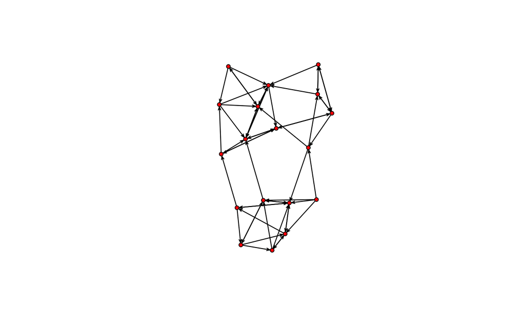

```r
plot(samplk3)
```

```r
summary(samplk3~edges+mutual)
```

```
 edges mutual
    56     15
```

The plot now shows the direction of a tie, and the $g(y)$ statistics for this model in this network are 56 total ties and 15 mutual dyads. This means 30 of the 56 ties are reciprocated, i.e., they are part of dyads in which both directional ties are present.

```r
sampmodel.01 <- ergm(samplk3~edges+mutual)
summary(sampmodel.01)
```

```
==========================
Summary of model fit
==========================

Formula:   samplk3 ~ edges + mutual

Iterations:  2 out of 20

Monte Carlo MLE Results:
       Estimate Std. Error MCMC % z value Pr(>|z|)
edges   -2.1572     0.2199      0  -9.808   <1e-04 ***
mutual   2.2973     0.4814      0   4.772   <1e-04 ***
---
Signif. codes:  0 '***' 0.001 '**' 0.01 '*' 0.05 '.' 0.1 ' ' 1

     Null Deviance: 424.2  on 306  degrees of freedom
 Residual Deviance: 268.2  on 304  degrees of freedom

AIC: 272.2    BIC: 279.7    (Smaller is better.)
```

There is a strong and significant mutuality effect. The coefficients for the edges and mutual terms roughly cancel for a mutual tie, so the conditional log-odds of a mutual tie are about zero, which means the probability is about 50%. (Do you see why a log-odds of zero corresponds to a probability of 50%?) By contrast, a non-mutual tie has a conditional log-odds of -2.16, or 10% probability.

Triangle terms in directed networks can have many different configurations, given the directional ties. Many of these configurations are coded as ergm-terms (and we’ll talk about these more below).

## 2. Missing data

It is important to distinguish between the absence of a tie and the absence of data on whether a tie exists. The former is an observed zero, whereas the latter is unobserved. You should not code both of these as “0”. The `ergm` package recognizes and handles missing data appropriately, as long as you identify the data as missing. Let’s explore this with a simple example.

```r
missnet <- network.initialize(10,directed=F) # initialize an empty net with 10 nodes
missnet[1,2] <- missnet[2,7] <- missnet[3,6] <- 1 # add a few ties
missnet[4,6] <- missnet[4,9] <- missnet[5,6] <- NA # mark a few dyads missing
summary(missnet)
```

```
Network attributes:
  vertices = 10
  directed = FALSE
  hyper = FALSE
  loops = FALSE
  multiple = FALSE
  bipartite = FALSE
 total edges = 6
   missing edges = 3
   non-missing edges = 3
 density = 0.06666667

Vertex attributes:
  vertex.names:
   character valued attribute
   10 valid vertex names

No edge attributes

Network adjacency matrix:
   1 2 3  4  5  6 7 8  9 10
1  0 1 0  0  0  0 0 0  0  0
2  1 0 0  0  0  0 1 0  0  0
3  0 0 0  0  0  1 0 0  0  0
4  0 0 0  0  0 NA 0 0 NA  0
5  0 0 0  0  0 NA 0 0  0  0
6  0 0 1 NA NA  0 0 0  0  0
7  0 1 0  0  0  0 0 0  0  0
8  0 0 0  0  0  0 0 0  0  0
9  0 0 0 NA  0  0 0 0  0  0
10 0 0 0  0  0  0 0 0  0  0
```

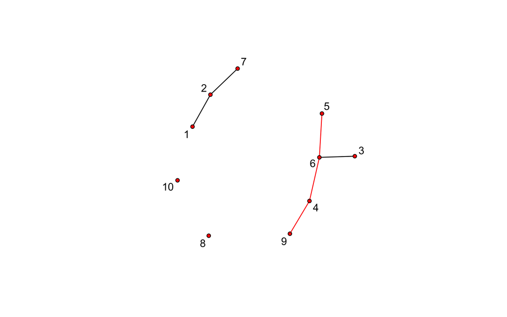

```r
# plot missnet with missing dyads colored red.
tempnet <- missnet
tempnet[4,6] <- tempnet[4,9] <- tempnet[5,6] <- 1
missnetmat <- as.matrix(missnet)
missnetmat[is.na(missnetmat)] <- 2
plot(tempnet,label = network.vertex.names(tempnet),
     edge.col = missnetmat)
```

```r
# fit an ergm to the network with missing data identified
summary(missnet~edges)
```

```
edges
    3
```

```r
summary(ergm(missnet~edges))
```

```
Starting maximum pseudolikelihood estimation (MPLE):
```

```
Evaluating the predictor and response matrix.
```

```
Maximizing the pseudolikelihood.
```

```
Finished MPLE.
```

```
Stopping at the initial estimate.
```

```
Evaluating log-likelihood at the estimate.
```

```
==========================
Summary of model fit
==========================

Formula:   missnet ~ edges

Iterations:  5 out of 20

Monte Carlo MLE Results:
      Estimate Std. Error MCMC % z value Pr(>|z|)
edges  -2.5649     0.5991      0  -4.281   <1e-04 ***
---
Signif. codes:  0 '***' 0.001 '**' 0.01 '*' 0.05 '.' 0.1 ' ' 1

     Null Deviance: 58.22  on 42  degrees of freedom
 Residual Deviance: 21.61  on 41  degrees of freedom

AIC: 23.61    BIC: 25.35    (Smaller is better.)
```

The coefficient equals -2.56, which corresponds to a probability of 7.14%. Our network has 3 ties, out of the 42 non-missing nodal pairs (10 choose 2 minus 3): 3/42 = 7.14%. So our estimate represents the probability of a tie in the observed sample.

Now let’s assign those missing ties the (observed) value “0” and check how the value of the coefficient will change. Can you predict whether it will get bigger or smaller? Can you calculate it directly before checking the output of an `ergm` fit? Let’s see what happens.

```r
missnet_bad <- missnet # create network with missing dyads set to 0
missnet_bad[4,6] <- missnet_bad[4,9] <- missnet_bad[5,6] <- 0

# fit an ergm to the network with missing dyads set to 0
summary(missnet_bad)
```

```
Network attributes:
  vertices = 10
  directed = FALSE
  hyper = FALSE
  loops = FALSE
  multiple = FALSE
  bipartite = FALSE
 total edges = 3
   missing edges = 0
   non-missing edges = 3
 density = 0.06666667

Vertex attributes:
  vertex.names:
   character valued attribute
   10 valid vertex names

No edge attributes

Network adjacency matrix:
   1 2 3 4 5 6 7 8 9 10
1  0 1 0 0 0 0 0 0 0  0
2  1 0 0 0 0 0 1 0 0  0
3  0 0 0 0 0 1 0 0 0  0
4  0 0 0 0 0 0 0 0 0  0
5  0 0 0 0 0 0 0 0 0  0
6  0 0 1 0 0 0 0 0 0  0
7  0 1 0 0 0 0 0 0 0  0
8  0 0 0 0 0 0 0 0 0  0
9  0 0 0 0 0 0 0 0 0  0
10 0 0 0 0 0 0 0 0 0  0
```

```r
summary(ergm(missnet_bad~edges))
```

```
Starting maximum pseudolikelihood estimation (MPLE):
```

```
Evaluating the predictor and response matrix.
```

```
Maximizing the pseudolikelihood.
```

```
Finished MPLE.
```

```
Stopping at the initial estimate.
```

```
Evaluating log-likelihood at the estimate.
```

```
==========================
Summary of model fit
==========================

Formula:   missnet_bad ~ edges

Iterations:  5 out of 20

Monte Carlo MLE Results:
      Estimate Std. Error MCMC % z value Pr(>|z|)
edges  -2.6391     0.5976      0  -4.416   <1e-04 ***
---
Signif. codes:  0 '***' 0.001 '**' 0.01 '*' 0.05 '.' 0.1 ' ' 1

     Null Deviance: 62.38  on 45  degrees of freedom
 Residual Deviance: 22.04  on 44  degrees of freedom

AIC: 24.04    BIC: 25.85    (Smaller is better.)
```

The coefficient is smaller now because the missing ties are counted as “0”, and this translates to a conditional tie probability of 6.67%.  
It’s a small difference in this case (and a small network, with little missing data).

MORAL: If you have missing data on ties, be sure to identify them by assigning the “NA” code. This is particularly important if you’re reading in data as an edgelist, as all dyads without edges are implicitly set to “0” in this case.

## 3. Model terms available for *ergm* estimation and simulation

Model terms are the expressions (e.g. “triangle”) used to represent predictors on the right-hand size of equations used in:

- calls to `summary` (to obtain measurements of network statistics on a dataset)
- calls to `ergm` (to estimate an ergm model)
- calls to `simulate` (to simulate networks from an ergm model fit)

Because these terms are not exogeneous measures, but functions of the dyad states in the network, they must be calculated for the network that is being modeled. Many ERGM terms are simple counts of configurations (e.g., edges, nodal degrees, stars, triangles), but others are more complex functions of these configurations (e.g., geometrically weighted degrees and shared partners). In theory, any configuration (or function of configurations) can be a term in an ERGM. In practice, however, these terms have to be constructed before they can be used—that is, one has to explicitly write an algorithm that defines and calculates the network statistic of interest. This is another key way that ERGMs differ from traditional linear and general linear models.

The terms that can be used in a model also depend on the type of network being analyzed: directed or undirected, one-mode or two-mode (“bipartite”), binary or valued edges.

### Terms provided with ergm

For a list of available terms that can be used to specify an ERGM, type:

```r
help('ergm-terms')
```

A table of commonly used terms can be found [here](https://statnet.github.io/nme/d2-ergmterms.html)

A more complete discussion of many of these terms can be found in the ‘Specifications’ paper in the [*Journal of Statistical Software v24(4)*](http://www.jstatsoft.org/v24/i04)

Finally, note that models with only dyad independent terms are estimated in statnet using a logistic regression algorithm to maximize the likelihood. Dyad dependent terms require a different approach to estimation, which, in statnet, is based on a Monte Carlo Markov Chain (MCMC) algorithm that stochastically approximates the Maximum Likelihood.

### Coding new ergm-terms

There is a `statnet` package — `ergm.userterms` — that provides the utilities needed to write new ergm-terms. The package is available on CRAN, and installing it will include the tutorial (ergmuserterms.pdf). The tutorial can also be found in the [*Journal of Statistical Software 52(2)*](http://www.jstatsoft.org/v52/i02), and some introductory slides and installation instructions from the workshop we teach on coding ergm-terms can be found [here](https://github.com/statnet/Workshops/tree/master/ergm.userterms).

Note that writing up new `ergm` terms requires some knowledge of C and the ability to build R from source. While the latter is covered in the tutorial, the many environments for building R and the rapid changes in these environments make these instructions obsolete quickly.

## 4. Assessing convergence for dyad dependent models: MCMC Diagnostics

For these models, it is important to assess model convergence before interpreting the model results – before evaluating statistical significance, interpreting coefficients, or assessing goodness of fit.  
To do this, we use the function `mcmc.diagnostics`.

Below we show a simple example of a model that converges, and how to use the MCMC diagnostics to identify this.

### What it looks like when a model converges properly

We will first consider a simple dyadic dependent model where the algorithm works using the program defaults, with a degree(1) term that captures whether there are more (or less) degree 1 nodes than we would expect, given the density.

```r
summary(flobusiness~edges+degree(1))
```

```
  edges degree1
     15       3
```

```r
fit <- ergm(flobusiness~edges+degree(1))
summary(fit)
```

```
==========================
Summary of model fit
==========================

Formula:   flobusiness ~ edges + degree(1)

Iterations:  2 out of 20

Monte Carlo MLE Results:
        Estimate Std. Error MCMC % z value Pr(>|z|)
edges    -2.1120     0.2973      0  -7.103   <1e-04 ***
degree1  -0.6711     0.6734      0  -0.997    0.319
---
Signif. codes:  0 '***' 0.001 '**' 0.01 '*' 0.05 '.' 0.1 ' ' 1

     Null Deviance: 166.4  on 120  degrees of freedom
 Residual Deviance:  89.4  on 118  degrees of freedom

AIC: 93.4    BIC: 98.97    (Smaller is better.)
```

```r
mcmc.diagnostics(fit)
```

```
Sample statistics summary:

Iterations = 16384:4209664
Thinning interval = 1024
Number of chains = 1
Sample size per chain = 4096

1. Empirical mean and standard deviation for each variable,
   plus standard error of the mean:

           Mean    SD Naive SE Time-series SE
edges   0.14868 3.716  0.05806        0.05806
degree1 0.04736 1.641  0.02563        0.02632

2. Quantiles for each variable:

        2.5% 25% 50% 75% 97.5%
edges     -7  -2   0   3     8
degree1   -3  -1   0   1     3


Sample statistics cross-correlations:
             edges    degree1
edges    1.0000000 -0.4248076
degree1 -0.4248076  1.0000000

Sample statistics auto-correlation:
Chain 1
                edges      degree1
Lag 0     1.000000000  1.000000000
Lag 1024 -0.012358715 -0.010637881
Lag 2048  0.002339375  0.036899728
Lag 3072 -0.012245481 -0.008918575
Lag 4096  0.012405526 -0.011632306
Lag 5120 -0.016940207 -0.004097006

Sample statistics burn-in diagnostic (Geweke):
Chain 1

Fraction in 1st window = 0.1
Fraction in 2nd window = 0.5

  edges degree1
-1.2403  0.3242

Individual P-values (lower = worse):
    edges   degree1
0.2148492 0.7458011
Joint P-value (lower = worse):  0.4568938 .
```

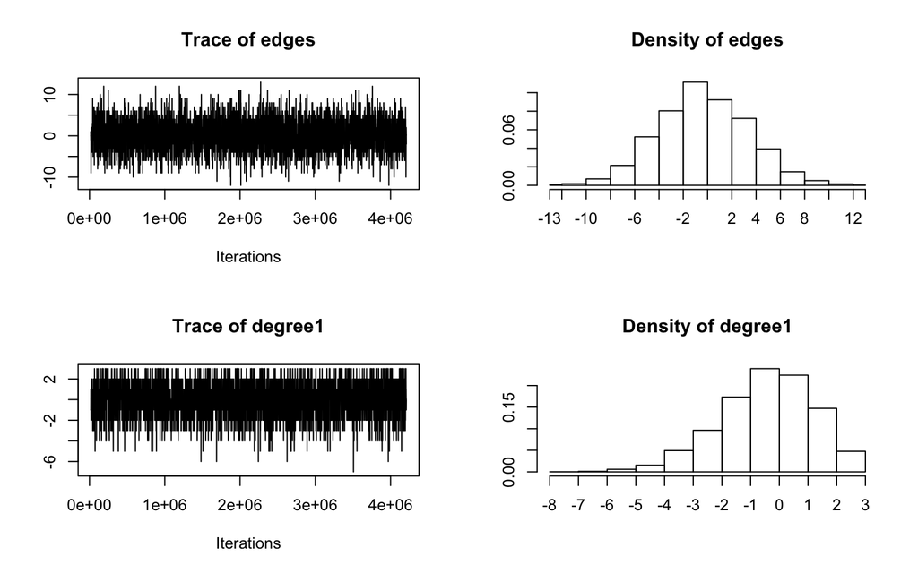

[output not shown]

What this shows is statistics from the final iteration of the MCMC chain, on the left as a “traceplot” (the deviation of the statistic value in each sampled network from the observed value), and on the right as the distribution of the sample statistic deviations.

This is what you want to see in the MCMC diagnostics: the MCMC sample statistics are varying randomly around the observed values at each step (so the chain is “mixing” well), the sampled values show little serial correlation (so they are independent draws from the graph space) and the difference between the observed and simulated values of the sample statistics have a roughly bell-shaped distribution, centered at 0. The sawtooth pattern visible on the degree term deviation plot is due to the combination of discrete values and small range in the statistics: the observed number of degree 1 nodes is 3, and only a few discrete values are produced by the simulations. So the sawtooth pattern is is an inherent property of the statistic, not a problem with the fit.

There are many control parameters for the MCMC algorithm (“help(control.ergm)”), and we’ll play with some of these below. To see what the algorithm is doing at each step, you can drop the sampling interval down to 1:

```r
fit <- ergm(flobusiness~edges+degree(1),
            control=control.ergm(MCMC.interval=1))
```

This runs a version with every network returned, and might be useful if you are trying to debug a bad model fit.

In the last section we’ll look at some models that don’t converge properly, and how to use MCMC diagnostics to identify and address this.

## 5. Network simulation: the *simulate* command and *network.list* objects

Once we have estimated the coefficients of an ERGM, the model is completely specified. It defines a probability distribution across all networks of this size. If the model is a good fit to the observed data, then networks drawn from this distribution will be more likely to “resemble” the observed data.

We use simulations from the model as a way to assess its “goodness of fit”, and that assessment should be done before using simulation for other purposes. But we will take a quick look here at how the simulation function works.

The `simulate` command is easy to run:

```r
flomodel.03.sim <- simulate(flomodel.03,nsim=10)

class(flomodel.03.sim) # what does this produce?
```

```
[1] "network.list"
```

```r
summary(flomodel.03.sim) # quick summary
```

```
Number of Networks: 10
Model: flomarriage ~ edges + nodecov("wealth")
Reference: ~Bernoulli
Constraints: TNT NULL 16   , 1    , 15   , 2    , 14   , 3    , 13   , 4    , 12   , 5    , 11   , 6    , 10   , 7    , 9    , 8    , 8    , 9    , 7    , 10   , 6    , 11   , 5    , 12   , 4    , 13   , 3    , 14   , 2    , 15   , 1    , FALSE, TRUE , FALSE, TRUE , FALSE, TRUE , FALSE, TRUE , FALSE…
Parameters:
         edges nodecov.wealth
   -2.59492903     0.01054591

Stored network statistics:
      edges nodecov.wealth
 [1,]    25           2326
 [2,]    19           2232
 [3,]    23           2515
 [4,]    19           2022
 [5,]    13           1205
 [6,]    11           1079
 [7,]    23           3199
 [8,]    20           2453
 [9,]    21           2291
[10,]    22           2428
attr(,"monitored")
[1] FALSE FALSE
```

[output not shown]

```r
attributes(flomodel.03.sim) # what's in this object?
```

[output not shown]

[output cut: 67 more lines]

[output not shown]

```r
# are the simulated stats centered on the observed stats?
rbind("obs"=summary(flomarriage~edges+nodecov("wealth")),
      "sim mean"=colMeans(attr(flomodel.03.sim, "stats")))
```

```
         edges nodecov.wealth
obs       20.0           2168
sim mean  19.6           2175
```

```r
# we can also plot individual simulations
flomodel.03.sim[[1]]
```

```
 Network attributes:
  vertices = 16
  directed = FALSE
  hyper = FALSE
  loops = FALSE
  multiple = FALSE
  bipartite = FALSE
  total edges= 25
    missing edges= 0
    non-missing edges= 25

 Vertex attribute names:
    priorates totalties vertex.names wealth

No edge attributes
```

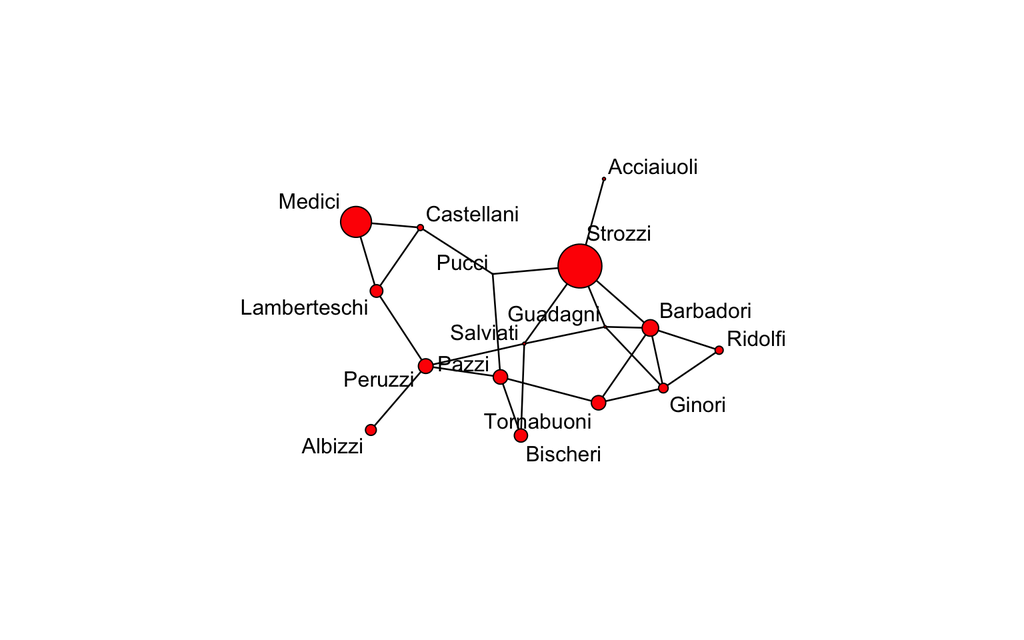

```r
plot(flomodel.03.sim[[1]],
     label= flomodel.03.sim[[1]] %v% "vertex.names",
     vertex.cex = (flomodel.03.sim[[1]] %v% "wealth")/25)
```

Voila. Of course, yours will look somewhat different.

Simulation from a model is a very powerful tool for examining the range of variation that can be expected from this model, both in the sufficient statistics that define the model, and in other statistics not explicitly specified by the model. Simulation plays a large role in analyizing egocentrically sampled data, and if you take the `tergm` workshop, you will see how we can use simulation to examine the temporal implications of a model based on a single cross-sectional egocentrically sampled dataset.

Next, we will examine the primary use of simulation in the ergm package: we simulate networks from the fitted model to evaluate goodness of fit to the observed network.

## 6. Examining the quality of model fit – GOF

ERGMs can be seen as generative models when they represent the process that governs the global patterns of tie prevalence from a local perspective: the perspective of the nodes involved in the particular micro-configurations represented by the ergm-terms in the model. The locally generated processes in turn aggregate up to produce characteristic global network properties, even though these global properties are not explicit terms in the model.

One test of whether a local model “fits the data” is therefore how well it reproduces the observed global network properties *that are not in the model*. We do this by choosing a network statistic that is not in the model, and comparing the value of this statistic observed in the original network to the distribution of values we get in simulated networks from our model, using the **gof** function.

The **gof** function is a bit different than the **summary**, **ergm**, and **simulate** functions, in that it currently only takes 3 ergm-terms as arguments: degree, esp (edgwise share partners), and distance (geodesic distances). Each of these terms captures an aggregate network distribution, at either the node level (degree), the edge level (esp), or the dyad level (distance).

```r
flomodel.03.gof <- gof(flomodel.03)
flomodel.03.gof
```

```
Goodness-of-fit for degree

   obs min mean max MC p-value
0    1   0 1.10   4       1.00
1    4   1 3.63   9       0.92
2    2   1 4.03   7       0.30
3    6   0 3.43   8       0.18
4    2   0 1.98   6       1.00
5    0   0 0.93   4       0.62
6    1   0 0.53   3       0.82
7    0   0 0.22   2       1.00
8    0   0 0.11   1       1.00
9    0   0 0.03   1       1.00
10   0   0 0.01   1       1.00

Goodness-of-fit for edgewise shared partner

     obs min  mean max MC p-value
esp0  12   4 12.41  21       1.00
esp1   7   0  6.03  15       0.92
esp2   1   0  1.55  10       1.00
esp3   0   0  0.24   5       1.00
esp4   0   0  0.02   1       1.00
esp6   0   0  0.01   1       1.00

Goodness-of-fit for minimum geodesic distance

    obs min  mean max MC p-value
1    20  12 20.26  30       1.00
2    35  18 35.13  65       1.00
3    32   6 27.46  42       0.52
4    15   0 11.99  27       0.70
5     3   0  3.78  16       1.00
6     0   0  1.01  12       1.00
7     0   0  0.24   6       1.00
8     0   0  0.03   1       1.00
Inf  15   0 20.10  82       1.00

Goodness-of-fit for model statistics

                obs  min    mean  max MC p-value
edges            20   12   20.26   30       1.00
nodecov.wealth 2168 1200 2226.51 3525       0.94
```

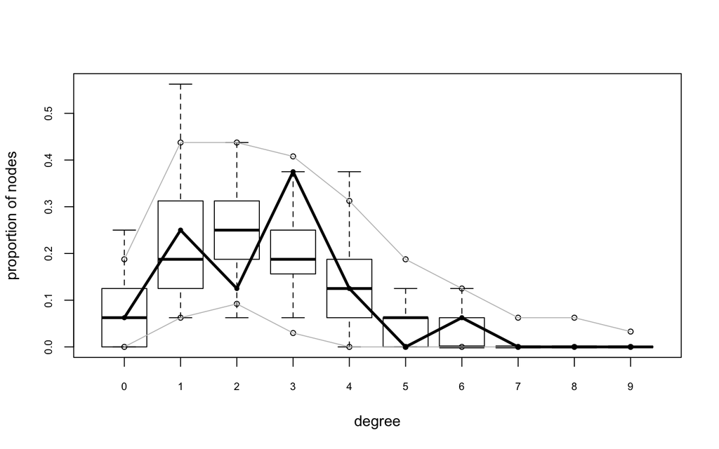

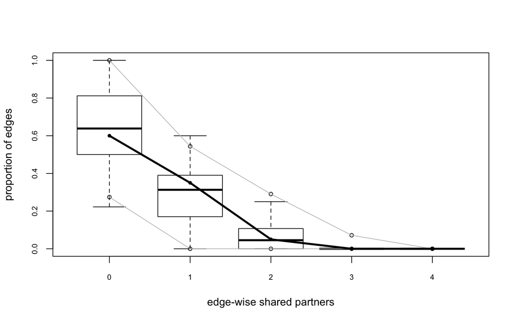

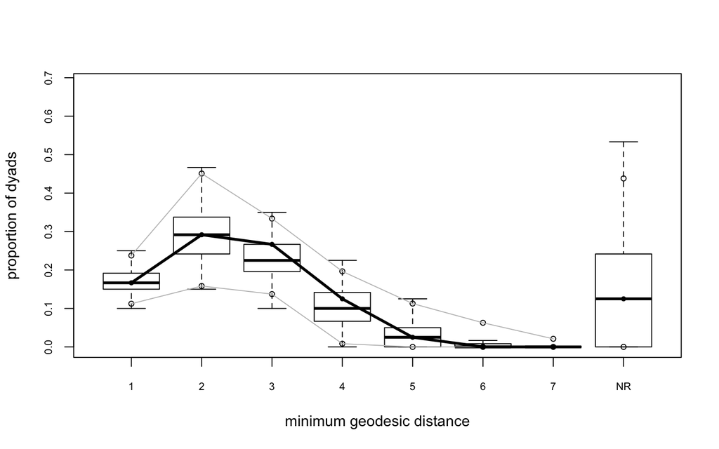

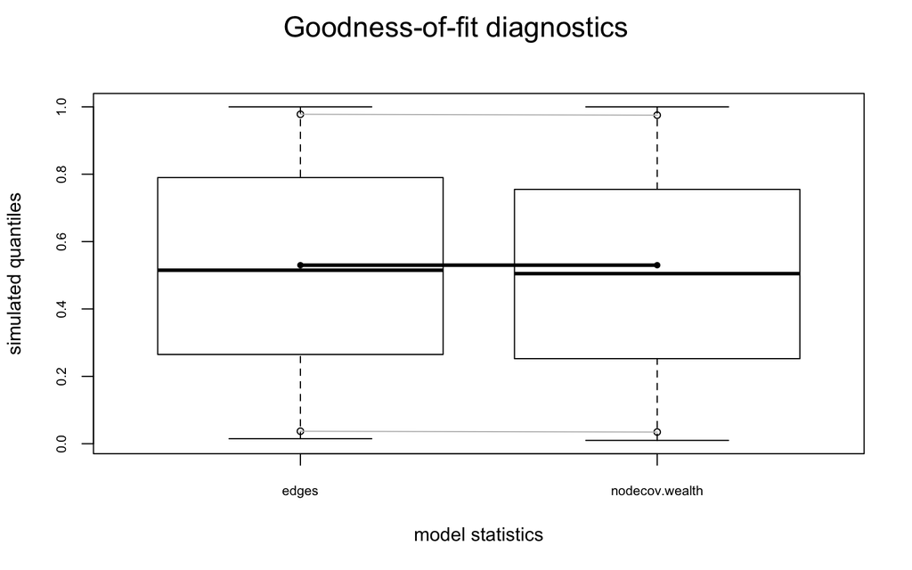

```r
plot(flomodel.03.gof)
```

```r
mesamodel.02 <- ergm(mesa~edges)
```

```
Starting maximum pseudolikelihood estimation (MPLE):
```

```
Evaluating the predictor and response matrix.
```

```
Maximizing the pseudolikelihood.
```

```
Finished MPLE.
```

```
Stopping at the initial estimate.
```

```
Evaluating log-likelihood at the estimate.
```

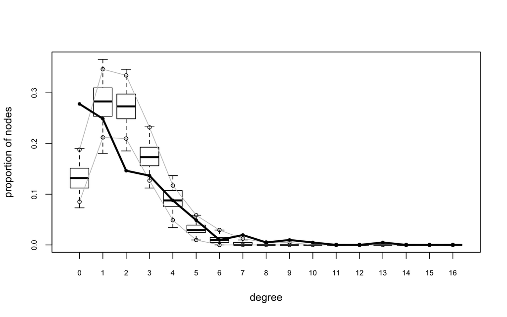

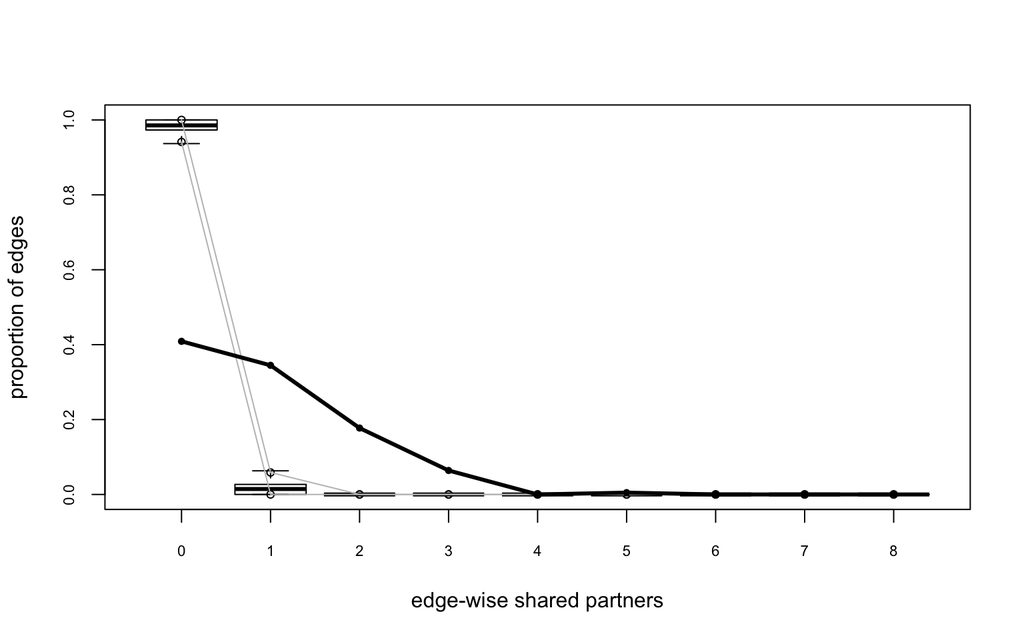

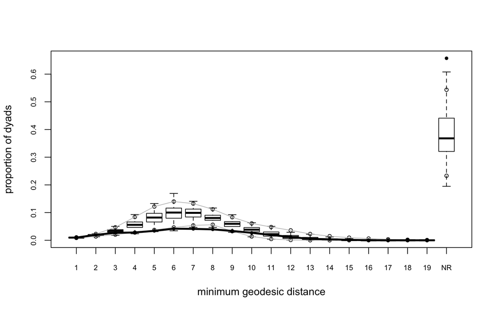

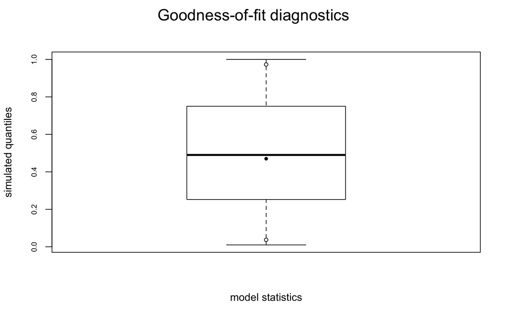

```r
mesamodel.02.gof <- gof(mesamodel.02~degree + esp + distance,
                        control.gof.formula(nsim=10))
plot(mesamodel.02.gof)
```

For a good example of model exploration and fitting for the Add Health Friendship networks, see [Goodreau, Kitts & Morris, *Demography* 2009](http://link.springer.com/article/10.1353/dem.0.0045).  
For more technical details on the approach, see [Hunter, Goodreau and Handcock *JASA* 2008](http://amstat.tandfonline.com/doi/abs/10.1198/016214507000000446?journalCode=uasa20#.U7HZgPldWSo)

## 7. Diagnostics: troubleshooting and checking for model degeneracy

When a model is not a good representation of the observed network, the simulated networks produced in the MCMC chains may be far enough away from the observed network that the estimation process is affected. In the worst case scenario, the simulated networks will be so different that the algorithm fails altogether. When this happens, it basically means the model you specified would not have produced the network you observed. Some models, we now know, would almost never produce an interesting network with this density – this is what we call “model degneracy.”

For more detailed discussion of model degeneracy in the ERGM context, see the papers by Mark Handcock referenced below.

In that worst case scenario, we end up not being able to obtain coefficent estimates, so we can’t use the GOF function to identify how the model simulations deviate from the observed data. We can, however, still use the MCMC diagnostics to observe what is happening with the simulation algorithm, and this (plus some experience and intuition about the behavior of ergm-terms) can help us improve the model specification.

### What it looks like when a model fails

For this, we’ll using a larger network, faux.magnolia.high, and look at a simple model for triad closure.

```r
data('faux.magnolia.high')
magnolia <- faux.magnolia.high
magnolia
```

```
 Network attributes:
  vertices = 1461
  directed = FALSE
  hyper = FALSE
  loops = FALSE
  multiple = FALSE
  bipartite = FALSE
  total edges= 974
    missing edges= 0
    non-missing edges= 974

 Vertex attribute names:
    Grade Race Sex vertex.names

 Edge attribute names not shown
```

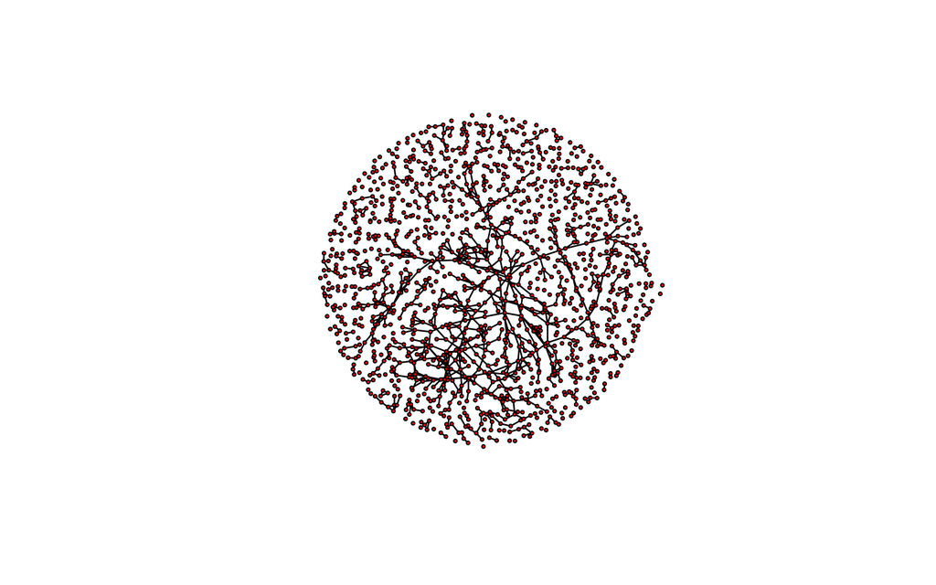

```r
plot(magnolia, vertex.cex=.5)
```

```r
# Consider a simple model
summary(magnolia~edges+triangle)
```

```
   edges triangle
     974      169
```

If we try to fit this “simple” model:

```r
fit <- ergm(magnolia~edges+triangle)
```

```
Iteration 1 of at most 20:
Convergence test P-value: 1.4e-87
The log-likelihood improved by 1.183
Iteration 2 of at most 20:
Convergence test P-value: 3.8e-04
The log-likelihood improved by 0.1518
Iteration 3 of at most 20:
```

```
Error: Number of edges in a simulated network exceeds that in the observed by a factor of more than 20. This is a strong indicator of model degeneracy. If you are reasonably certain that this is not the case, increase the MCMLE.density.guard control.ergm() parameter.
```

Very interesting. Instead of converging, the algorithm heads off into networks that are much much more dense than the observed network. This is such a clear indicator of a degenerate model specification that the algorithm stops after 3 iterations, to avoid heading off into areas that would cause memory issues. If you’d like to peek a bit more under the hood, you can stop the algorithm earlier to catch where it’s heading:

```r
fit <- ergm(magnolia~edges+triangle,
            control=control.ergm(MCMLE.maxit=2))
```

```
Starting maximum likelihood estimation via MCMLE:

Iteration 1 of at most 2:
Optimizing with step length 0.707275631968435.
The log-likelihood improved by 8.688.

Iteration 2 of at most 2:
Optimizing with step length 1.
The log-likelihood improved by 3.539.

Step length converged once. Increasing MCMC sample size.

MCMLE estimation did not converge after 2 iterations. The estimated coefficients may not be accurate. Estimation may be resumed by passing the coefficients as initial values; see 'init' under ?control.ergm for details.

 ... (output snipped)

This model was fit using MCMC.  To examine model diagnostics and check for degeneracy, use the mcmc.diagnostics() function.
```

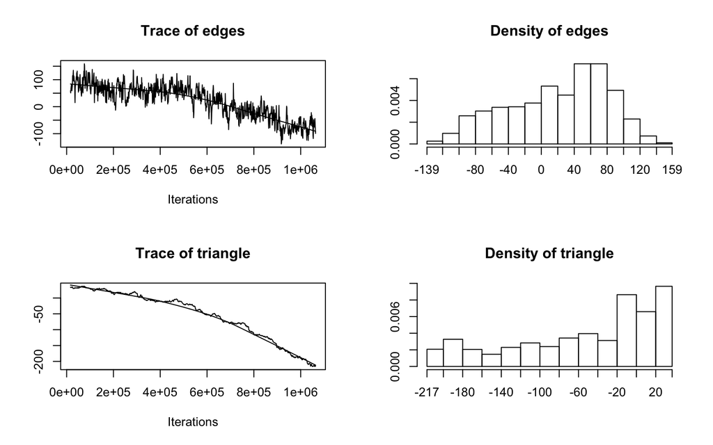

```r
mcmc.diagnostics(fit)
```

Clearly, somewhere very bad.

This turns out to be one of the classic degenerate specifications, and we now understand much more about why it does not produce reasonable levels of triadic closure.

We also now have more robust version of modeling triangles: the geometrically-weighed edgewise shared partner term (GWESP). (For a technical introduction to GWESP see [Hunter and Handcock, 2006](http://www.tandfonline.com/doi/abs/10.1198/106186006X133069#.U6R5WfldWSo); for a more intuitive description and empirical application see [Goodreau, Kitts & Morris, 2009](http://link.springer.com/article/10.1353/dem.0.0045) )

```r
fit <- ergm(magnolia~edges+gwesp(0.25,fixed=T),
            verbose=T)
mcmc.diagnostics(fit)
```

```
Sample statistics summary:

Iterations = 16384:4209664
Thinning interval = 1024
Number of chains = 1
Sample size per chain = 4096

1. Empirical mean and standard deviation for each variable,
   plus standard error of the mean:

                   Mean    SD Naive SE Time-series SE
edges            0.2087 40.12   0.6269          9.728
gwesp.fixed.0.25 0.5953 31.70   0.4952         10.530

2. Quantiles for each variable:

                   2.5%    25%   50%   75% 97.5%
edges            -82.00 -27.00 4.000 29.00 71.00
gwesp.fixed.0.25 -67.93 -17.94 9.834 23.05 50.39


Sample statistics cross-correlations:
                     edges gwesp.fixed.0.25
edges            1.0000000        0.8096504
gwesp.fixed.0.25 0.8096504        1.0000000

Sample statistics auto-correlation:
Chain 1
             edges gwesp.fixed.0.25
Lag 0    1.0000000        1.0000000
Lag 1024 0.8467254        0.9955847
Lag 2048 0.7633263        0.9911867
Lag 3072 0.7222326        0.9867951
Lag 4096 0.6921311        0.9823692
Lag 5120 0.6758300        0.9779419

Sample statistics burn-in diagnostic (Geweke):
Chain 1

Fraction in 1st window = 0.1
Fraction in 2nd window = 0.5

           edges gwesp.fixed.0.25
          0.2025           0.3141

Individual P-values (lower = worse):
           edges gwesp.fixed.0.25
       0.8395158        0.7534277
Joint P-value (lower = worse):  0.4418057 .
```

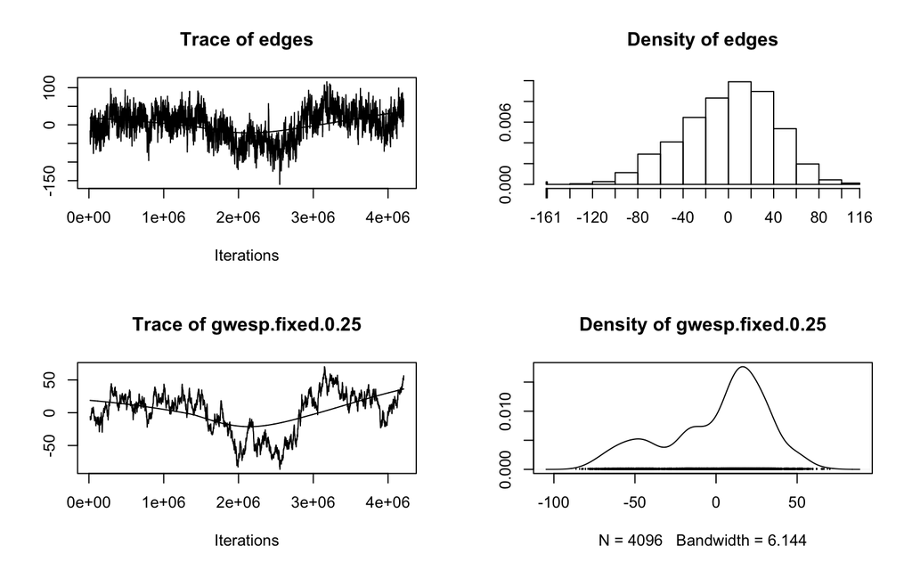

[output not shown]

[output not shown]

Better, but not great. Here we’ll change two things – add some more reasonable terms to the model, and add in some robustness to the fitting algorithm by making the MCMC simulation longer.

```r
fit <- ergm(magnolia~edges+gwesp(0.25,fixed=T)+nodematch('Grade')+
              nodematch('Race')+nodematch('Sex'),
            control = control.ergm(MCMC.interval=10000),
            verbose=T)
```

```
Evaluating network in model.
```

```
Initializing Metropolis-Hastings proposal(s): ergm:MH_TNT
Using initial method 'MPLE'.
Fitting initial model.
Starting maximum pseudolikelihood estimation (MPLE):
Evaluating the predictor and response matrix.
MPLE covariate matrix has 211 rows.
Maximizing the pseudolikelihood.
Finished MPLE.
Starting Monte Carlo maximum likelihood estimation (MCMLE):
Density guard set to 19563 from an initial count of 974 edges.

Iteration 1 of at most 20 with parameter:
           edges gwesp.fixed.0.25  nodematch.Grade   nodematch.Race
      -9.8619687        1.6946112        2.8534613        0.9886313
   nodematch.Sex
       0.8245285
Starting unconstrained MCMC...
Back from unconstrained MCMC.
Average estimating function values:
           edges gwesp.fixed.0.25  nodematch.Grade   nodematch.Race
       104.61523         42.10209        102.99121         99.24512
   nodematch.Sex
        92.20020
Starting MCMLE Optimization...
NOTE: Messages 'Error in mcexit(0L)...' may appear; please disregard them.
Optimizing with step length 0.718583437937866.
Using lognormal metric (see control.ergm function).
Using log-normal approx (no optim)
The log-likelihood improved by 2.912.

Iteration 2 of at most 20 with parameter:
           edges gwesp.fixed.0.25  nodematch.Grade   nodematch.Race
      -9.7885410        1.7706879        2.7785100        0.9129889
   nodematch.Sex
       0.7837285
Starting unconstrained MCMC...
Back from unconstrained MCMC.
Average estimating function values:
           edges gwesp.fixed.0.25  nodematch.Grade   nodematch.Race
       28.343750         8.918309        27.281250        23.912109
```

[output cut: 17 more lines]

```
           edges gwesp.fixed.0.25  nodematch.Grade   nodematch.Race
        5.160889         4.851242         4.422363         3.528320
   nodematch.Sex
        8.068848
Starting MCMLE Optimization...
Optimizing with step length 1.
Using lognormal metric (see control.ergm function).
Using log-normal approx (no optim)
Starting MCMC s.e. computation.
The log-likelihood improved by 0.03913.
Step length converged twice. Stopping.
Finished MCMLE.
Evaluating log-likelihood at the estimate. Using 20 bridges: 1 2 3 4 5 6 7 8 9 10 11 12 13 14 15 16 17 18 19 20 .
This model was fit using MCMC.  To examine model diagnostics and
check for degeneracy, use the mcmc.diagnostics() function.
```

```r
mcmc.diagnostics(fit)
```

```
Sample statistics summary:

Iterations = 160000:41110000
Thinning interval = 10000
Number of chains = 1
Sample size per chain = 4096

1. Empirical mean and standard deviation for each variable,
   plus standard error of the mean:

                   Mean    SD Naive SE Time-series SE
edges            -5.161 46.00   0.7187          6.201
gwesp.fixed.0.25 -4.851 41.21   0.6439          6.883
nodematch.Grade  -4.422 43.95   0.6867          6.268
nodematch.Race   -3.528 43.13   0.6738          6.440
nodematch.Sex    -8.069 39.66   0.6197          6.089

2. Quantiles for each variable:

                   2.5%    25%   50%  75% 97.5%
edges            -96.00 -36.00 -4.00 25.0 84.62
gwesp.fixed.0.25 -87.17 -32.38 -3.05 21.2 74.77
nodematch.Grade  -93.62 -33.00 -4.00 25.0 82.00
nodematch.Race   -89.62 -32.00 -3.00 24.0 83.00
nodematch.Sex    -86.00 -35.00 -8.00 19.0 70.00


Sample statistics cross-correlations:
                     edges gwesp.fixed.0.25 nodematch.Grade nodematch.Race
edges            1.0000000        0.8438592       0.9591829      0.9445376
gwesp.fixed.0.25 0.8438592        1.0000000       0.8644409      0.8434291
nodematch.Grade  0.9591829        0.8644409       1.0000000      0.9180792
nodematch.Race   0.9445376        0.8434291       0.9180792      1.0000000
nodematch.Sex    0.9039561        0.7949251       0.8695474      0.8586096
                 nodematch.Sex
edges                0.9039561
gwesp.fixed.0.25     0.7949251
nodematch.Grade      0.8695474
nodematch.Race       0.8586096
nodematch.Sex        1.0000000
```

[output cut: 20 more lines]

```

Fraction in 1st window = 0.1
Fraction in 2nd window = 0.5

           edges gwesp.fixed.0.25  nodematch.Grade   nodematch.Race
          -1.567           -1.263           -1.283           -1.570
   nodematch.Sex
          -1.620

Individual P-values (lower = worse):
           edges gwesp.fixed.0.25  nodematch.Grade   nodematch.Race
       0.1169993        0.2065332        0.1993851        0.1164363
   nodematch.Sex
       0.1052061
Joint P-value (lower = worse):  0.01045046 .
```

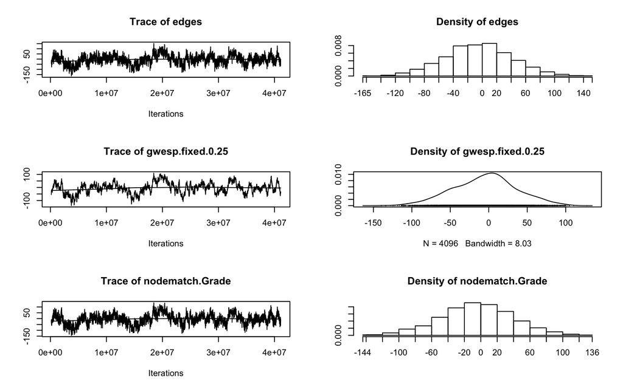

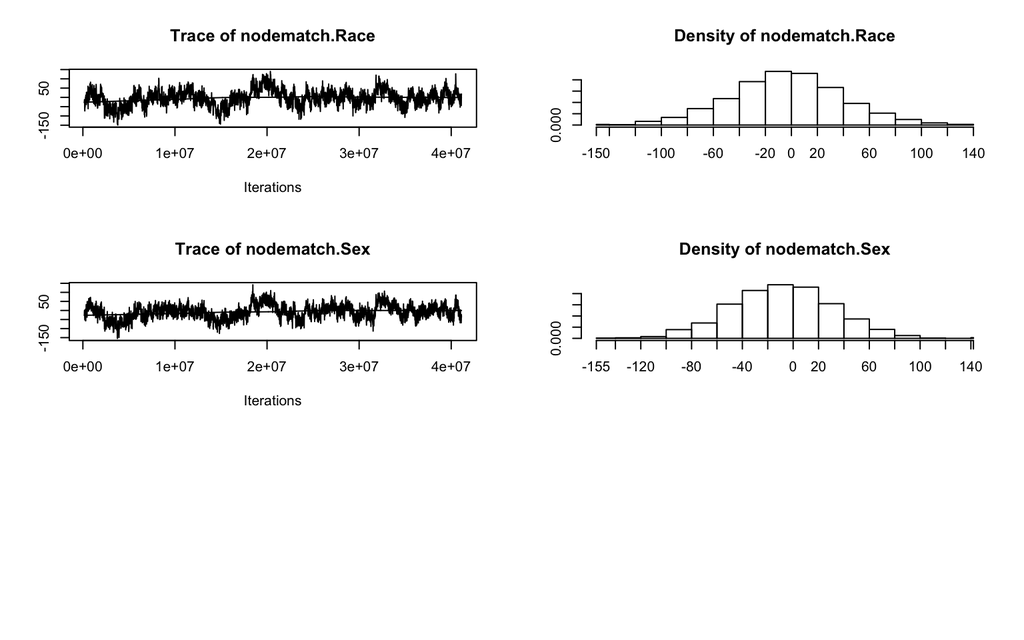

[output not shown]

**MORAL:** Degeneracy is an indicator of a poorly specified model. It is not a property of all ERGMs, but it is associated with some dyadic-dependent terms, in particular, the reduced homogenous Markov specifications (e.g., 2-stars and triangle terms). For a good technical discussion of unstable terms see [Schweinberger 2012.](http://www.tandfonline.com/doi/abs/10.1198/jasa.2011.tm10747#.U6R2FvldWSo) For a discussion of alternative terms that exhibit more stable behavior see [Snijders et al. 2006.](http://onlinelibrary.wiley.com/doi/10.1111/j.1467-9531.2006.00176.x/abstract) and for the gwesp term (and the curved exponential family terms in general) see [Hunter and Handcock 2006.](http://amstat.tandfonline.com/doi/abs/10.1198/106186006X133069#.U7MxWPldWSo)

## 8. Working with egocentrically sampled network data

One of the most powerful features of ERGMs is that they can be used to estimate models from from egocentrically sampled data, and the fitted models can then be used to simulate complete networks (of any size) that will have the properties of the original network that are observed and represented in the model.

In many empirical contexts, it is not feasible to collect a network census or even an adaptive (link-traced) sample. Even when one of these may be possible in practice, egocentrically sampled data are typically cheaper and easier to collect.

Long regarded as the poor country cousin in the network data family, egocentric data contain a remarkable amount of information. With the right statistical methods, such data can be used to explore the properties of the complete networks in which they are embedded. The basic idea here is to combine what is observed, with assumptions, to define a class of models that describe the distribution of networks that are centered on the observed properties. The variation in these networks quantifies some of the uncertainty introduced by the assumptions.

The egocentric estimation/simulation framework extends to temporal ERGMs (“TERGMs”) as well, with the minimal addition of an estimate of partnership duration. This makes it possible to simulate complete dynamic networks from a single cross-sectional egocentrically sampled network. For an example of what you can do with this, check out the network movie we developed to explore the impact of dynamic network structure on HIV transmission, see http://statnet.org/movies

While the `ergm` package has had this capability for many years (and old ERGM worshops had a section on this), there is now a specific package that makes this much easier: `ergm.ego`. The new package includes accurate statistical inference (so you can get standard errors for model coefficients), and many utilities that simplify the task of reading in the data, conducting exploratory analyses, calculating the sample “target statistics”, and specifying model options.

We now have a separate workshop/tutorial for `ergm.ego`, so we no longer cover this material in the current ERGM workshop. As always, this workshop material can be found online at the [statnet Workshops wiki](https://github.com/statnet/Workshops/wiki).

## 9. Additional functionality in statnet and other package

`statnet` is actually a suite of packages that are designed to work together, and provide tools for a wide range of different types of network data analysis. Examples include temporal network models and dynamic network vizualizations, analysis of egocentrically sampled network data, multilevel network modeling, latent cluster models and network diffusion and epidemic models. Development is ongoing, and there are new packages, and new functionality added to existing packages on a regular basis.

All of these packages can be downloaded from CRAN. For more detailed information, please visit the `statnet` webpage [www.statnet.org](http://statnet.org).

### Current statnet packages

Packages developed by statnet team that are not covered in this tutorial:

- `sna` – classical social network analysis utilities
- `tsna` – descriptive statistics for temporal network data
- `tergm` – temporal ergms for dynamic networks
- `ergm.ego`– estimation/simulation of ergms from egocentrically sampled data
- `ergm.count` – models for tie count network data
- `ergm.rank` – models for tie rank network data
- `relevent` – relational event models for networks
- `latentnet` – latent space and latent cluster analysis
- `degreenet` – MLE estimation for degree distributions (negative binomial, Poisson, scale-free, etc.)
- `networksis` – simulation of bipartite networks with given degree distributions
- `ndtv` package – network movie maker
- `EpiModel` – network modeling of infectious disease and social diffusion processes

Many of these have associated training workshops. Our tutorials can be found online, on the [GitHub statnet Workshops wiki](https://statnet.github.io/Workshops).

### Additional functionality in base `ergm`

- ERGMs for valued ties

### Extensions by other developers

There are now a number of excellent packages developed by others that extend the functionality of statnet. The easiest way to find these is to look at the “reverse depends” of the `ergm` package on [CRAN](https://cran.org/packages). Examples include:

- `Bergm` – Bayesian Exponential Random Graph Models
- `btergm` – Temporal Exponential Random Graph Models by Bootstrapped Pseudolikelihood
- `hergm` – hierarchical ERGMs for multi-level network data
- `xergm` – extensions to ERGM modeling

### Statnet Commons: The development group

Mark S. Handcock handcock@stat.ucla.edu  
David R. Hunter dhunter@stat.psu.edu  
Carter T. Butts buttsc@uci.edu  
Steven M. Goodreau goodreau@u.washington.edu  
Skye Bender-deMoll skyebend@skyeome.net  
Martina Morris morrism@u.washington.edu  
Pavel N. Krivitsky pavel@uow.edu.au  
Samuel M. Jenness samuel.m.jenness@emory.edu

## Appendix A: Clarifying the terms – ergm and network

You will see the terms ergm and network used in multiple contexts throughout the documentation. This is common in R, but often confusing to newcomers. To clarify:

**ergm**

- **ERGM**: the acronym for an Exponential Random Graph Model; a statistical model for relational data that takes a generalized exponential family form.
- **ergm package**: one of the packages within the `statnet` suite
- **ergm function**: a function within the ergm package; fits an ERGM to a network object, creating an ergm object in the process.
- **ergm object**: a class of objects produced by a call to the ergm function, representing the results of an ERGM fit to a network.

**network**

- **network**: a set of actors and the relations among them. Used interchangeably with the term graph.
- **network package**: one of the packages within the `statnet` suite; used to create, store, modify and plot the information found in network objects.
- **network object**: a class of object in `R` used to represent a network.

## References

The best place to start is the special issue of the *Journal of Statistical Software* (JSS) devoted to `statnet`: [link](https://www.jstatsoft.org/issue/view/v024)

The nine papers in this issue cover a wide range of theoretical and practical topics related to ERGMs, and their implementation in `statnet`.

HOWEVER: Note that this issue was written in 2008. The statnet code base has evolved considerably since that time, so some of the syntax specified in the articles may no longer work (in most cases because it has been replace with something better).

For social scientists, a good introductory application paper is:

Goodreau, S., J. Kitts and M. Morris (2009). Birds of a Feather, or Friend of a Friend? Using Statistical Network Analysis to Investigate Adolescent Social Networks. *Demography* 46(1): 103-125. [link](http://link.springer.com/article/10.1353/dem.0.0045)

**Dealing with Model Degeneracy**

Handcock MS (2003a). “Assessing Degeneracy in Statistical Models of Social Networks.” Working Paper 39, Center for Statistics and the Social Sciences, University of Washington. [link](http://www.csss.washington.edu/research/working-papers/39)

Schweinberger, Michael (2011) Instability, Sensitivity, and Degeneracy of Discrete Exponential Families *JASA* 106(496): 1361-1370. [link](http://www.tandfonline.com/doi/abs/10.1198/jasa.2011.tm10747#.U7M4A_ldWSo)

Snijders, TAB et al (2006) New Specifications For Exponential Random Graph Models  
*Sociological Methodology* 36(1): 99-153 [link](http://onlinelibrary.wiley.com/doi/10.1111/j.1467-9531.2006.00176.x/abstract)

Hunter, D. R. (2007). Curved Exponential Family Models for Social Networks. *Social Networks*, 29(2), 216-230.[link](https://www.ncbi.nlm.nih.gov/pmc/articles/PMC2031865/)

**Temporal ERGMs**

Krivitsky, P.N., Handcock, M.S,(2014). A separable model for dynamic networks *JRSS Series B-Statistical Methodology*, 76(1):29-46; 10.1111/rssb.12014 JAN 2014 [link](https://www.ncbi.nlm.nih.gov/pmc/articles/PMC3891677/)

Krivitsky, P. N., M. S. Handcock and M. Morris (2011). Adjusting for Network Size and Composition Effects in Exponential-family Random Graph Models, *Statistical Methodology* 8(4): 319-339, ISSN 1572-3127 [link](https://www.ncbi.nlm.nih.gov/pmc/articles/PMC3117581/)

**Egocentric ERGMS**

Krivitsky, P. N., & Morris, M. (2017). Inference for social network models from egocentrically sampled data, with application to understanding persistent racial disparities in HIV prevalence in the US. *Annals of Applied Statistics*, 11(1), 427-455.[link](https://www.ncbi.nlm.nih.gov/pmc/articles/PMC5737754/)